# Final Project R Reference

Julia Vineyard

12/2/2021

# R Reference Guide

## Loading Data and Packages

### here()

- here() lets you direct R to where you data is located in your directory
- To load here() you must use require(here) first
- Using here() first also tells you where R is currently pulling your data from

```r
require(here)
```

### read.csv()

- Then you can combine here() with read.csv() to make a dataframe and bring it into the environment
- read.csv() allows R to read the data file that you are directing it to into a dataframe
- You can name the dataframe whatever you want

```r
ginkgo= read.csv(here("data", "ginkgo_data_2021.csv"))
```

### library()

- The library() function is another way to bring in a package, but only from the R directory
- You can name the dataframe whatever you want

```r
palmer_penguins= library(palmerpenguins)
```

## Data Structures

### c()

The function c() combines or concatenates its arguments into a vector (a 1-dimensional data structure consisting of 1 or more elements).

- All of the elements must be of the same type
- I can’t combine character and numeric types in the same call to c()

Here’s two examples using numeric and character data types:

```r
## Create a vector of numbers:
num_vec  = c(1, 4, 8, 9, 13)

## Create a vector of characters:
char_vec = c("a", "fish", "data is cool")
```

You can show the contents of a vector by typing the name of the vector, or using the print() function.

```r
## Typing the name of the vector into the console prints the contents
num_vec
```

```
## [1]  1  4  8  9 13
```

```r
## The print() function accomplishes the same task:
print(char_vec)
```

```
## [1] "a"            "fish"         "data is cool"
```

### length()

The length() function allows you to see how many pieces are in a list or other object in your environment.

```r
length(char_vec)
```

```
## [1] 3
```

```r
length(num_vec)
```

```
## [1] 5
```

### matrix()

The matrix() function allow you to create a matrix from a given set of values or a vector.

```r
matrix(num_vec)
```

```
##      [,1]
## [1,]    1
## [2,]    4
## [3,]    8
## [4,]    9
## [5,]   13
```

```r
matrix(1:8)
```

```
##      [,1]
## [1,]    1
## [2,]    2
## [3,]    3
## [4,]    4
## [5,]    5
## [6,]    6
## [7,]    7
## [8,]    8
```

You can also specify the number of rows and columns in a matrix.

```r
matrix(1:8, ncol=2, nrow=4)
```

```
##      [,1] [,2]
## [1,]    1    5
## [2,]    2    6
## [3,]    3    7
## [4,]    4    8
```

R defaults to filling the matrix by columns, but you can change it to fill by row.

```r
matrix(1:8, ncol=2, nrow=4, byrow=TRUE)
```

```
##      [,1] [,2]
## [1,]    1    2
## [2,]    3    4
## [3,]    5    6
## [4,]    7    8
```

### data.frame()

The data.frame() allows you to load data into R’s environment as a collection of variables. A data frame can store many different types of data into 1 data frame, while a matrix is limited to only 1 type of data (usually numbers).

```r
num_data= data.frame(num_vec)

char_data= data.frame(char_vec)
```

Now that the data is in a data frame you can view it as a collection, rather than a string of numbers.

```r
num_data
```

```
##   num_vec
## 1       1
## 2       4
## 3       8
## 4       9
## 5      13
```

```r
num_vec
```

```
## [1]  1  4  8  9 13
```

### nrow()

The nrow() function produces the number of rows in the data frame (or matrix) you input.

```r
nrow(ginkgo)
```

```
## [1] 756
```

### ncol()

Then ncol() function produes the number of columns in the data frame (or matrix) you input.

```r
ncol(ginkgo)
```

```
## [1] 6
```

### dim()

The dim() function produces the dimensions of the data frame (or matrix) you input.

```r
dim(ginkgo)
```

```
## [1] 756   6
```

## Subsetting

### $

Using the $ to subset allows you to pull out a specific named part of the data.

```r
width= ginkgo$max_width
```

### []

```r
ginkgo[1]
```

```
##     ï..site_id
## 1         7719
## 2         7719
## 3         7719
## 4         7719
## 5         7719
## 6         7719
## 7         7719
## 8         7719
## 9         7719
## 10        7719
## 11        7719
## 12        7719
## 13        7719
## 14        7719
```

[output cut: 742 more lines]

To select the element in row 2, column 3

```r
ginkgo[2,3]
```

```
## [1] 64
```

To select the 3rd column of the ginkgo data

```r
ginkgo[,3]
```

```
##   [1]  71.0  64.0  55.0  62.0  65.0  70.0  63.0  56.0  51.0  57.0  59.0  63.0
##  [13]  70.0  50.0  56.0  46.0  54.0  62.0  56.0  55.0  59.0  60.0  63.0  61.0
##  [25]  58.0  55.0  53.0  81.0  94.0  75.0  82.0  86.0  79.0  93.0  88.0  76.0
##  [37]  71.0  91.0  71.0  82.0  65.0  83.0  73.0 102.0  78.0  88.0  81.0  70.0
##  [49]  80.0  96.0  80.0  82.0  86.0  87.0  89.0  69.0  93.0  98.0  81.0  79.0
##  [61]  82.0  85.0  81.0  59.0  53.0  83.0  80.0  77.0  81.0  76.0  82.0  81.0
##  [73]  77.0  68.0  41.0  70.0  68.0  80.0  89.0  90.0  71.0  64.0  55.0  62.0
##  [85]  65.0  70.0  63.0  56.0  51.0  57.0  59.0  63.0  70.0  50.0  56.0  46.0
##  [97]  54.0  62.0  56.0  55.0  59.0  60.0  63.0  61.0  58.0  55.0  53.0  77.0
## [109]  72.0  57.0  75.0  75.0  75.0  67.0  74.0  71.0  72.0  55.0  77.0  97.0
## [121]  73.0  64.0  69.0  92.0  64.0  68.0  53.0  97.0 100.0  90.0  89.0  59.0
## [133]  97.0  76.0  85.0  90.0  87.0  85.0  80.0  86.0  89.0  84.0  88.0  80.0
## [145] 102.0  94.0  95.0 109.0  84.0  68.0  59.0  74.0  70.0  71.0  69.0  74.0
## [157]  70.0  78.0  87.0  69.0  60.0  72.0  59.0  75.0  81.0  82.0  74.0  72.0
## [169]  79.0  84.0  75.0  72.0  88.0  80.0  90.0  58.0  61.0  95.0  72.0  90.0
```

[output cut: 48 more lines]

### subset()

The subset() function allows you to pull out data based on a criteria that you set. To retrieve all the data for Adelie penguins from the penguins dataset:

```r
dat_adelie=subset(penguins, species=="Adelie")
```

## Numerical Data Exploration

### summary()

The summary() function gives you an overview of what the data contains for all data types.

```r
summary(penguins)
```

```
##       species          island    bill_length_mm  bill_depth_mm
##  Adelie   :152   Biscoe   :168   Min.   :32.10   Min.   :13.10
##  Chinstrap: 68   Dream    :124   1st Qu.:39.23   1st Qu.:15.60
##  Gentoo   :124   Torgersen: 52   Median :44.45   Median :17.30
##                                  Mean   :43.92   Mean   :17.15
##                                  3rd Qu.:48.50   3rd Qu.:18.70
##                                  Max.   :59.60   Max.   :21.50
##                                  NA's   :2       NA's   :2
##  flipper_length_mm  body_mass_g       sex           year
##  Min.   :172.0     Min.   :2700   female:165   Min.   :2007
##  1st Qu.:190.0     1st Qu.:3550   male  :168   1st Qu.:2007
##  Median :197.0     Median :4050   NA's  : 11   Median :2008
##  Mean   :200.9     Mean   :4202                Mean   :2008
##  3rd Qu.:213.0     3rd Qu.:4750                3rd Qu.:2009
##  Max.   :231.0     Max.   :6300                Max.   :2009
##  NA's   :2         NA's   :2
```

From this summary you can see that there are 124 Gentoo penguins listed in the species column and 52 rows of data listed as Torgersen island.

### mean()

The mean() function calculates the mean of the data you specify.

```r
mean(ginkgo$max_depth)
```

```
## [1] 58.51455
```

If you have a dataset that contains NAs, you must add in na.rm=TRUE

```r
mean(penguins$body_mass_g, na.rm=TRUE)
```

```
## [1] 4201.754
```

### sd()

The sd() function calculates the standard deviation of the data you specify.

```r
sd(ginkgo$max_depth)
```

```
## [1] 23.46108
```

If you have a dataset that contains NAs, you must add in na.rm=TRUE

```r
sd(penguins$body_mass_g, na.rm=TRUE)
```

```
## [1] 801.9545
```

## Graphical Data Exploration

### plot()

The plot() function allows you to create a scatterplot of the data you specify.

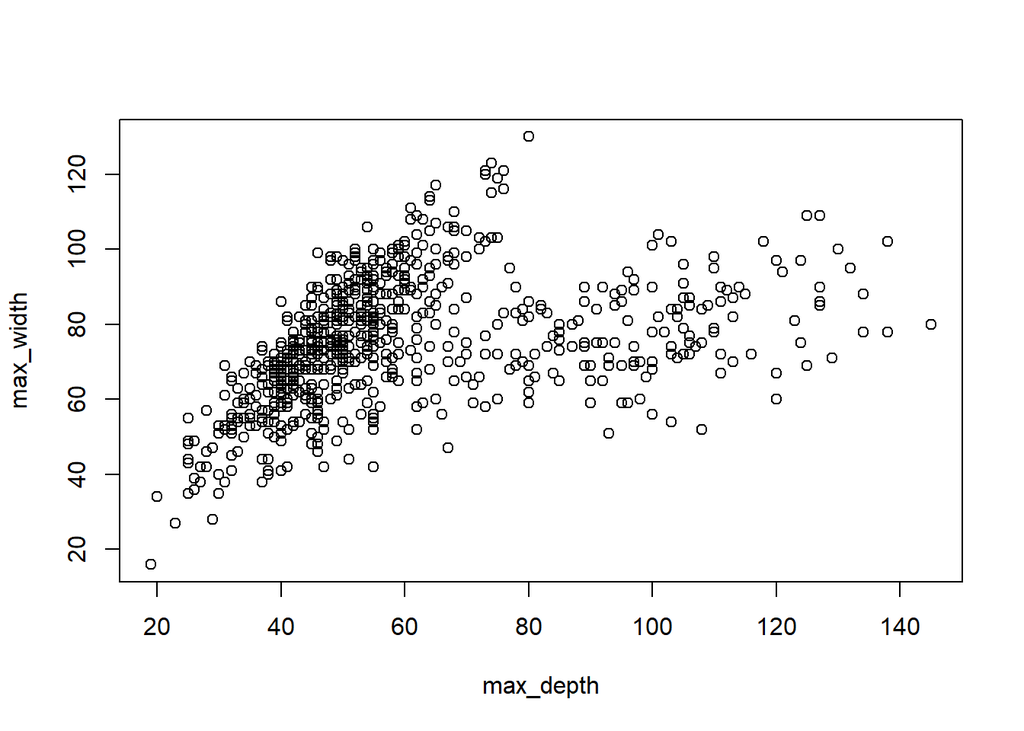

```r
plot(max_width ~ max_depth, data=ginkgo)
```

You can assign many different arguments for the plot() function including:

- col= Allows you to specify the color
- pch= Allows you to change the shape of the plotting character
- cex= Allows you to change the size of the plotting character
- main= Allows you to label the plot (title)
- xlab= Allows you to label the x-axis
- ylab= Allows you to label the y-axis
- xlim= Allows you to set the limits of the x-axis
- ylim= Allows you to set the limits of the y-axis

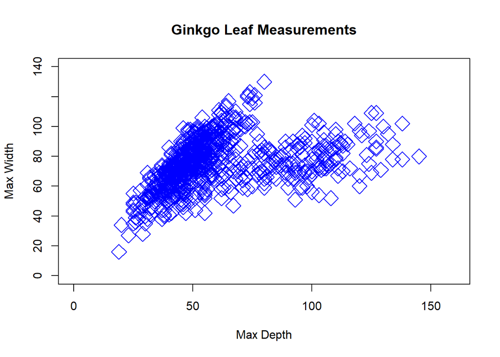

```r
plot(max_width ~ max_depth, data=ginkgo, col="blue", pch=5,
     cex=2, main="Ginkgo Leaf Measurements",
     xlab= "Max Depth", ylab= "Max Width",
     xlim=c(0,160), ylim=c(0,140))
```

### hist()

This hist() function allows you to make a histogram from the data you specify.

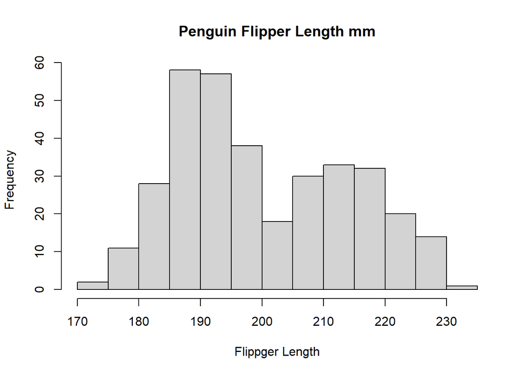

```r
hist(penguins$flipper_length_mm, xlab="Flippger Length", main="Penguin Flipper Length mm")
```

- breaks= Allows you to change the number of bars the histogram breaks the data into.

You can get a more detailed representation of the data with a greater number of breaks.

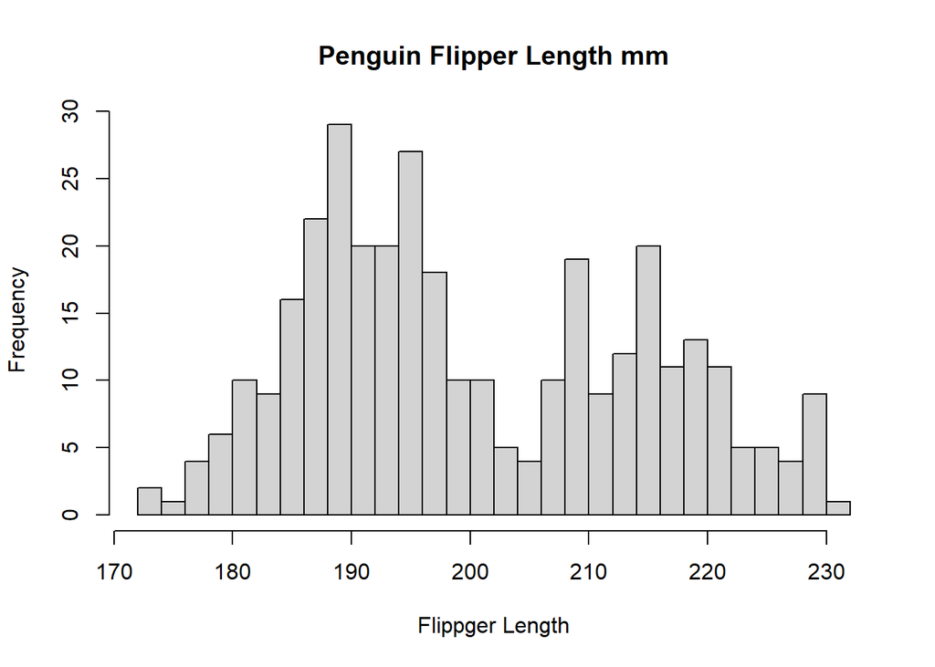

```r
hist(penguins$flipper_length_mm, breaks=30, xlab="Flippger Length", main="Penguin Flipper Length mm")
```

### boxplot()

The boxplot() function allows you to make a boxplot from the data you specify.

To create a simple boxplot of the Ginkgo petiole length:

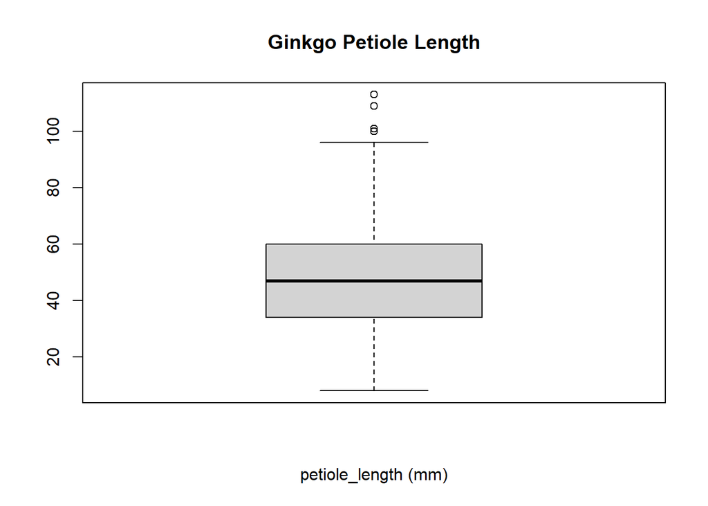

```r
boxplot(ginkgo$petiole_length, xlab="petiole_length (mm)", main="Ginkgo Petiole Length")
```

To create a conditional boxplot showing the continuous variable of notch depth conditioned on the seeds_present column:

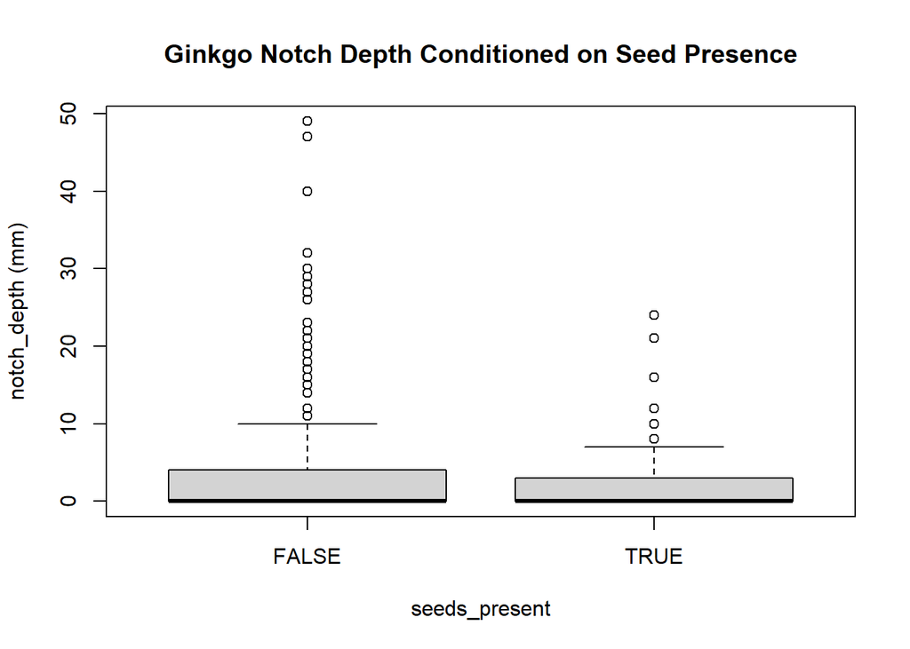

```r
boxplot(notch_depth ~ seeds_present, data=ginkgo, xlab="seeds_present", ylab= "notch_depth (mm)", main="Ginkgo Notch Depth Conditioned on Seed Presence")
```

### par(mfrow=)

The par() function combined with the mfrow= argument allows you to set the layout of the graphs you want to see at one time

Set mfrow=c(NUMBER OF ROWS, NUMBER OF COLUMNS) you want to have displayed

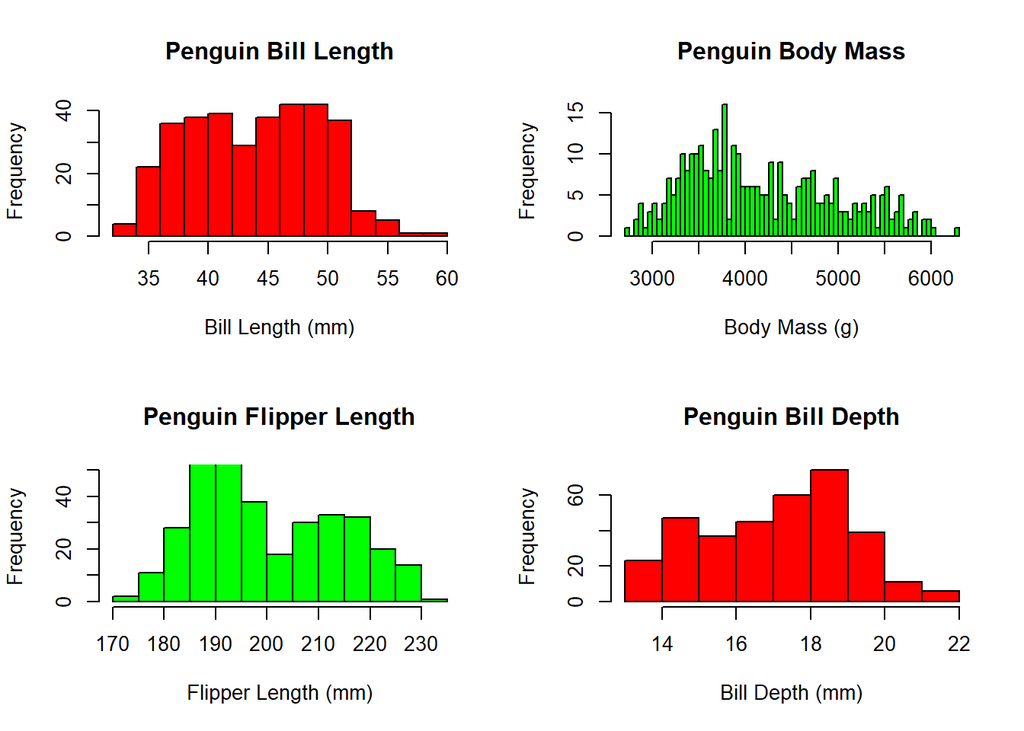

```r
par(mfrow= c(2,2))

hist(penguins$bill_length_mm, xlab="Bill Length (mm)", main="Penguin Bill Length",
     col="red")

hist(penguins$body_mass_g, breaks = 80, main = "Penguin Body Mass",
     xlab = "Body Mass (g)", col="green")

hist(penguins$flipper_length_mm,
     ylim = c(0,50),
     main="Penguin Flipper Length",
     xlab="Flipper Length (mm)",
     col= "green")

hist(penguins$bill_depth_mm,
     main="Penguin Bill Depth",
     xlab="Bill Depth (mm)",
     col= "red")
```

```r
dev.off()
```

## Distribution Functions

- dnorm(): the probability density, height of the curve

```r
dnorm(-1.96, mean=0, sd=1)
```

```
## [1] 0.05844094
```

- pnorm()l: the cumulative probability density, area underneath the curve

```r
pnorm(-1.96, mean=0, sd=1)
```

```
## [1] 0.0249979
```

- qnorm(): the quantile function

  You assign a probability and R gives you the boundary value

  If you want to find the 85th percentile of a normal distribution that has a mean of 70 and standard deviation of 3:

```r
qnorm(0.85,mean=70,sd=3)
```

```
## [1] 73.1093
```

- dbinom(): the probability mass function

  Allows you to ask: what is the probability that I observe a value of exactly x?

  Observing a count of exactly 3 successes, n=4, p=0.75

```r
 dbinom(3, 4, 0.75)
```

```
## [1] 0.421875
```

- pbinom(): the cumulative mass function

  Allows you to ask: what is the probability that I observe a value of x or less?

  observing a count of 3 or less, n=4, p=0.75 (3 or less includes 3)

```r
pbinom(3, 4, 0.75)
```

```
## [1] 0.6835937
```

observing more than 3, n=5, p=0.75 (more than 3 does not include 3)

```r
1- pbinom(3, 5, 0.75)
```

```
## [1] 0.6328125
```

- qbinom(): the quantile function

  Allows you to ask: what is the median or 50th percentile?

  If you want to find the 10th quantile of a binomial distribution with 10 trials and probability of success on each trial = 0.4

```r
qbinom(.10, size=10, prob=.4)
```

```
## [1] 2
```